# Practical Machine Learning Assignment

## Analysis

### Regression Tree

Now we fit a tree to these data, and summarize and plot it. First, we use the ‘tree’ package. It is much faster than ‘caret’ package.

```r
library(tree)
set.seed(12345)
tree.training=tree(classe~.,data=training)
summary(tree.training)
```

```
##
## Classification tree:
## tree(formula = classe ~ ., data = training)
## Variables actually used in tree construction:
##  [1] "pitch_forearm"     "magnet_belt_y"     "accel_forearm_z"
##  [4] "magnet_dumbbell_y" "roll_forearm"      "magnet_dumbbell_z"
##  [7] "pitch_belt"        "yaw_belt"          "accel_forearm_x"
## [10] "yaw_dumbbell"      "magnet_forearm_y"  "accel_dumbbell_z"
## [13] "gyros_belt_z"
## Number of terminal nodes:  19
## Residual mean deviance:  1.73 = 23700 / 13700
## Misclassification error rate: 0.343 = 4711 / 13737
```

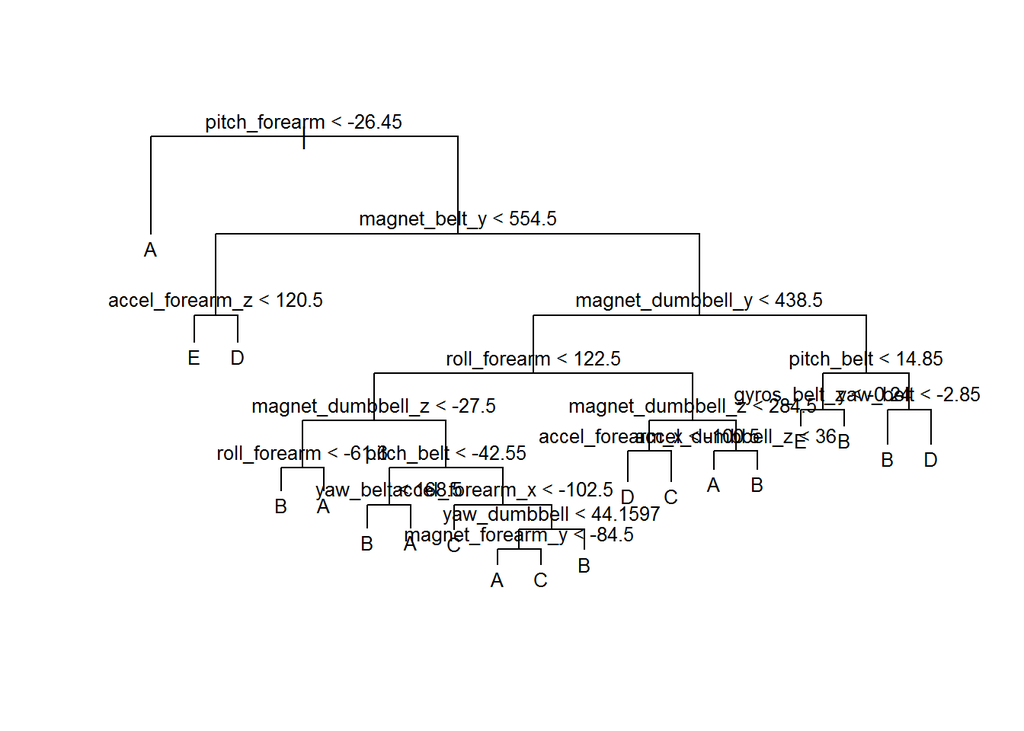

```r
plot(tree.training)
text(tree.training,pretty=0, cex =.8)
```

*We need to trim this tree.*

### Rpart form Caret

```r
library(caret)
modFit <- train(classe ~ .,method="rpart",data=training)
print(modFit$finalModel)
```

```
## n= 13737
##
## node), split, n, loss, yval, (yprob)
##       * denotes terminal node
##
##  1) root 13737 9831 A (0.28 0.19 0.17 0.16 0.18)
##    2) pitch_forearm< -33.95 1089    7 A (0.99 0.0064 0 0 0) *
##    3) pitch_forearm>=-33.95 12648 9824 A (0.22 0.21 0.19 0.18 0.2)
##      6) magnet_belt_y>=557.5 11604 8783 A (0.24 0.23 0.21 0.18 0.15)
##       12) magnet_dumbbell_y< 438.5 9668 6904 A (0.29 0.18 0.24 0.17 0.13)
##         24) roll_forearm< 123.5 6118 3643 A (0.4 0.17 0.18 0.15 0.092) *
##         25) roll_forearm>=123.5 3550 2339 C (0.081 0.18 0.34 0.21 0.18)
##           50) accel_forearm_x>=-107.5 2531 1549 C (0.09 0.22 0.39 0.086 0.22) *
##           51) accel_forearm_x< -107.5 1019  481 D (0.059 0.093 0.22 0.53 0.095) *
##       13) magnet_dumbbell_y>=438.5 1936 1013 B (0.029 0.48 0.041 0.2 0.25) *
##      7) magnet_belt_y< 557.5 1044  216 E (0.0029 0.011 0.0038 0.19 0.79) *
```

*Using Rattle for Graph*

```r
library(rattle)
```

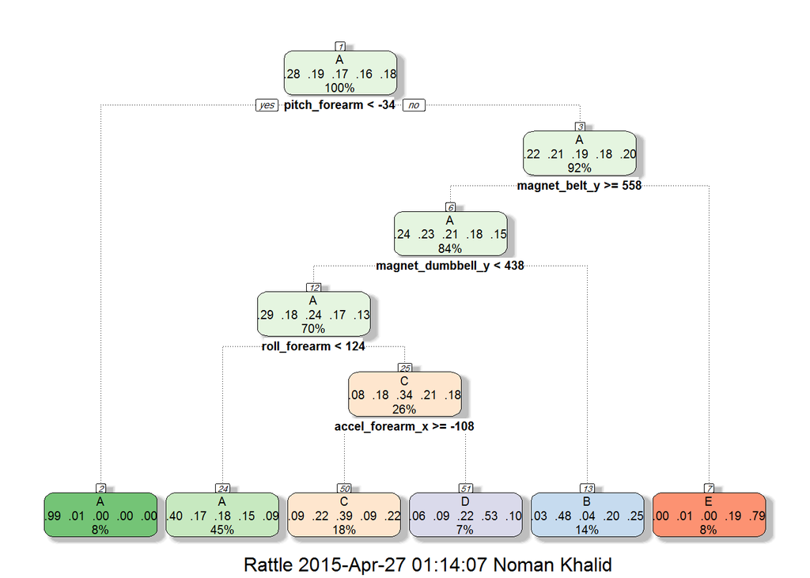

```r
library(rpart.plot)
fancyRpartPlot(modFit$finalModel)
```

## Cross Validation

We are going to check the performance of the tree on the testing data by cross validation.

```r
tree.pred=predict(tree.training,testing,type="class")
predMatrix = with(testing,table(tree.pred,classe))
sum(diag(predMatrix))/sum(as.vector(predMatrix)) # error rate
```

```
## [1] 0.6656
```

```r
tree.pred=predict(modFit,testing)
predMatrix = with(testing,table(tree.pred,classe))
sum(diag(predMatrix))/sum(as.vector(predMatrix)) # error rate
```

```
## [1] 0.4986
```

*0.50 from Caret Package is much less than the result from Decision Tree.*

### Modifying Tree

This tree was grown to full depth, and might be too variable. We now use Cross Validation to prune it.

```r
cv.training=cv.tree(tree.training,FUN=prune.misclass)
cv.training
```

```
## $size
## [1] 19 18 15 14 13 10  7  5  1
##
## $dev
## [1] 4575 4597 4919 5355 5421 6476 6887 7249 9831
##
## $k
## [1]  -Inf  51.0 126.0 157.0 160.0 196.0 224.3 257.5 649.5
##
## $method
## [1] "misclass"
##
## attr(,"class")
## [1] "prune"         "tree.sequence"
```

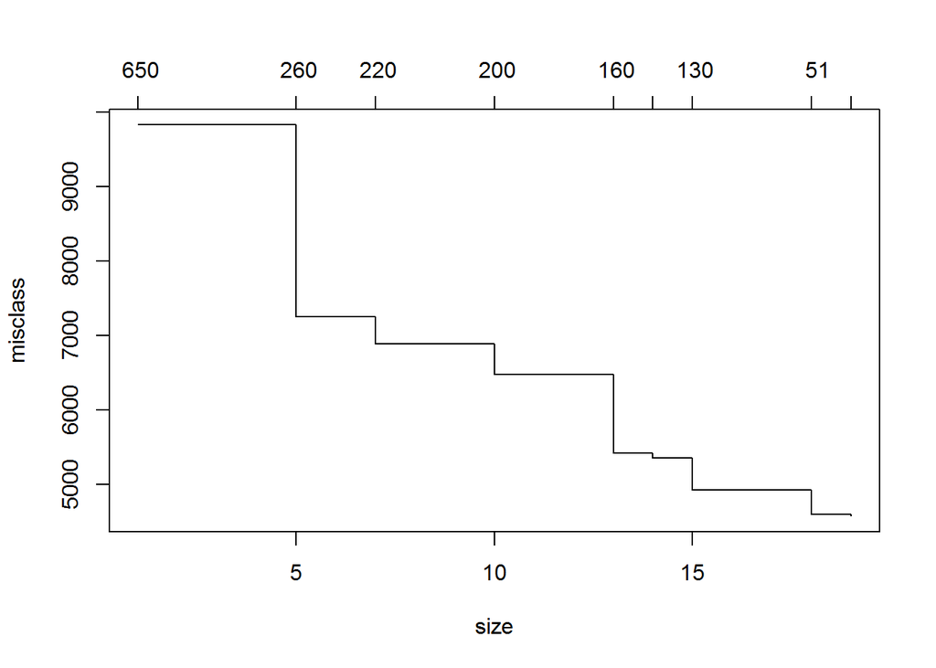

```r
plot(cv.training)
```

Suppose we prune it at size of nodes at 15.

```r
prune.training=prune.misclass(tree.training,best=15)
```

Now lets evaluate this pruned tree on the test data.

```r
tree.pred=predict(prune.training,testing,type="class")
predMatrix = with(testing,table(tree.pred,classe))
sum(diag(predMatrix))/sum(as.vector(predMatrix))
```

```
## [1] 0.6272
```

*The single tree is not good enough, so we are going to use bootstrap to improve the accuracy. We are going to try random forests.*

## Random Forests

Random forests build several trees, and then average them to reduce the variance.

```r
require(randomForest)
set.seed(12345)
```

*Testing a random forest*

```r
rf.training=randomForest(classe~.,data=training,ntree=100, importance=TRUE)
rf.training
```

```
##
## Call:
##  randomForest(formula = classe ~ ., data = training, ntree = 100,      importance = TRUE)
##                Type of random forest: classification
##                      Number of trees: 100
## No. of variables tried at each split: 6
##
##         OOB estimate of  error rate: 0.71%
## Confusion matrix:
##      A    B    C    D    E class.error
## A 3900    2    2    1    1    0.001536
## B   19 2628    9    0    2    0.011287
## C    0   21 2371    4    0    0.010434
## D    1    0   23 2226    2    0.011545
## E    0    0    3    7 2515    0.003960
```

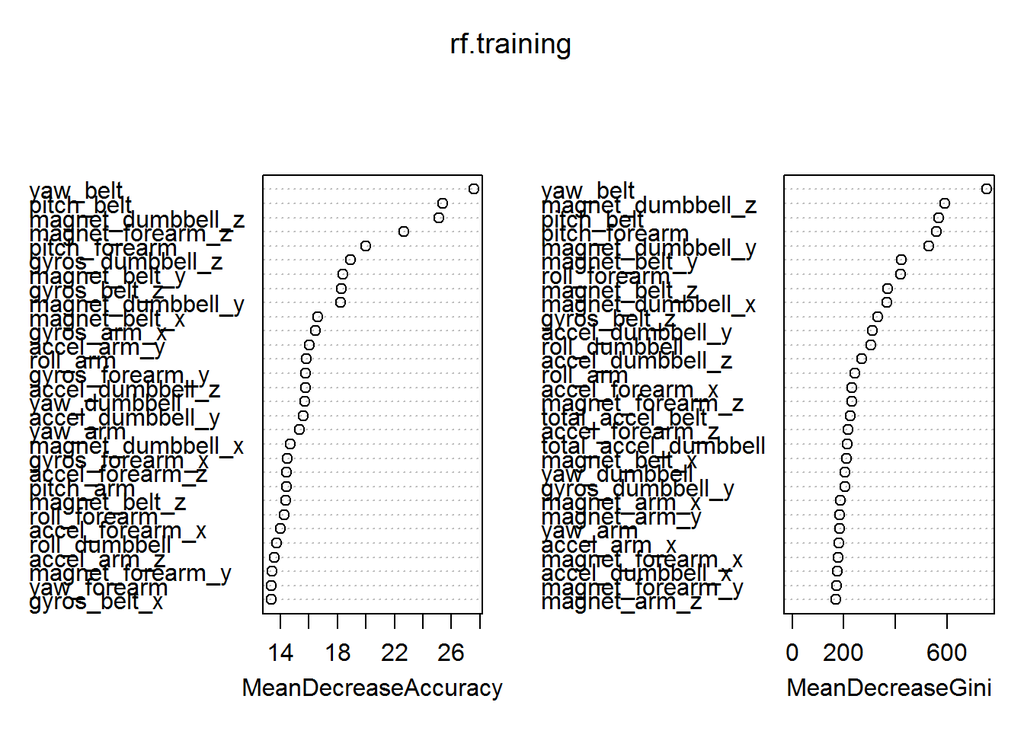

```r
varImpPlot(rf.training,)
```

**We can see which variables have higher impact on the prediction.**

### Out-of Sample Accuracy

Now lets evaluate this tree on the test data.

```r
tree.pred=predict(rf.training,testing,type="class")
predMatrix = with(testing,table(tree.pred,classe))
sum(diag(predMatrix))/sum(as.vector(predMatrix))
```

```
## [1] 0.9968
```

*0.99 means we got a very accurate estimate.*

No. of variables tried at each split: 6. It means every time we only randomly use 6 predictors to grow the tree. Since p = 43, we can have it from 1 to 43, but it seems 6 is enough to get the good result.

# Conclusion

Now we can predict the testing data from the website.

```r
answers <- predict(rf.training, testingOrg)
answers
```

```
##  1  2  3  4  5  6  7  8  9 10 11 12 13 14 15 16 17 18 19 20
##  B  A  B  A  A  E  D  B  A  A  B  C  B  A  E  E  A  B  B  B
## Levels: A B C D E
```

*Answer File Writing Code*

```r
#pml_write_files = function(x){
#        n = length(x)
#        for(i in 1:n){
#                filename = paste0("problem_id_",i,".txt")
#                write.table(x[i],file=filename,quote=FALSE,row.names=FALSE,col.names=FALSE)
#        }
#}

#pml_write_files(answers)
```